# Introduction to the Earthquake data visualization package

Sergey Kolchin

2018-05-20

This package implements some functions to visualize the data of Significant Earthquakes dataset provided by the National Oceanic and Atmospheric Administration (NOAA).

The package was written for the Capstone project assignment for the Johns Hopkins University “Mastering Software Development in R” specialization on Coursera.

## The Data

The dataset is available at the NOAA website ([download link](https://www.ngdc.noaa.gov/nndc/struts/results?type_0=Exact&query_0=$ID&t=101650&s=13&d=189&dfn=signif.txt)).

The dataset contains data for all majour earthquakes and tsunamis starting from 2150 B.C. Dataset definition is available at the site.

The package contains the downloaded file as of the May 2018.

## Loading and cleaning the data

To load the dataset, use `eq_load_data()` function:

```r
raw_data <- eq_load_data("signif.txt")
```

In order to use, the dataset needs to be cleaned by `eq_clean_data()` and `eq_location_clean()` functions.

The first one adds two extra variables, DATE, which holds a date of an event, and DATE_C, which is either “BC” or “AD”. Also, the function converts LATITUDE and LONGITUDE vaiables to numeric.

The second function strips country name from LOCATION_NAME variable and converts it to Title case.

```r
data <- raw_data %>% eq_clean_data() %>% eq_location_clean()
str(data)
```

```
#> Classes 'tbl_df', 'tbl' and 'data.frame':    6021 obs. of  49 variables:
#>  $ I_D                               : int  1 2 3 5877 8 11 9712 12 13 14 ...
#>  $ FLAG_TSUNAMI                      : chr  NA "Tsu" NA "Tsu" ...
#>  $ YEAR                              : int  -2150 -2000 -2000 -1610 -1566 -1450 -1365 -1250 -1050 -759 ...
#>  $ MONTH                             : num  1 1 1 1 1 1 1 1 1 1 ...
#>  $ DAY                               : num  1 1 1 1 1 1 1 1 1 1 ...
#>  $ HOUR                              : int  NA NA NA NA NA NA NA NA NA NA ...
#>  $ MINUTE                            : int  NA NA NA NA NA NA NA NA NA NA ...
#>  $ SECOND                            : chr  NA NA NA NA ...
#>  $ FOCAL_DEPTH                       : int  NA NA 18 NA NA NA NA NA NA NA ...
#>  $ EQ_PRIMARY                        : num  7.3 NA 7.1 NA NA NA NA 6.5 6.2 NA ...
#>  $ EQ_MAG_MW                         : num  NA NA NA NA NA NA NA NA NA NA ...
#>  $ EQ_MAG_MS                         : num  NA NA 7.1 NA NA NA NA NA NA NA ...
#>  $ EQ_MAG_MB                         : chr  NA NA NA NA ...
#>  $ EQ_MAG_ML                         : num  NA NA NA NA NA NA NA NA NA NA ...
```

[output cut: 35 more lines]

## Visualizating earthquakes on a timeline

The package provides visualization tools to be used with ggplot2 in order to display the eqarthquakes on a timeline.

The `geom_timeline()` function creates a timeline layer, which displays earthquakes on a timeline as points with the diameter relative to earthquake maginitude and color to number of deaths caused by it.

Required aestetic for the function is **x**, which should be a date variable. Optional aestetics are:

- **y**, which could be used to separate the timelines upon a variable (default is 0.1)
- **colour**
- **alpha**
- **fill**
- **size**

The `geom_timeline_label()` function adds location or other information to the displayed points.

Required aestetic for the function is **x**, which should be the same as in the timeline call, and **label**, which is to provide a name of variable to display. Optional aestetics are:

- **y**, which should be the same as in the main timeline
- **n_max**, which might be set to limit number of displayed labels to n_max largest (by magnitude) earthquakes
- **magnitude**, which has to be set to a column containing magnitude value if n_max is used

Additionally, the `theme_timeline()` function should be used to make a plot area formatted as a timeline.

Sample timeline (without stratification):

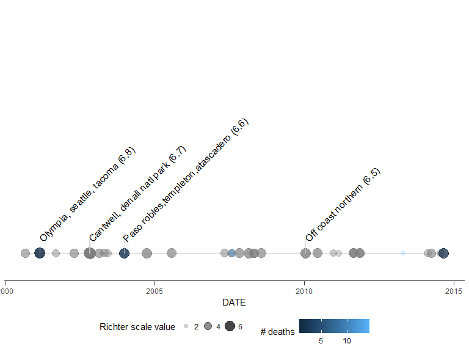

```r
h <- data %>%
 filter(YEAR >= 2000 & YEAR < 2015 & is.na(FLAG_TSUNAMI)) %>%
 filter(COUNTRY == "USA")


ggplot( h, aes (x = DATE )) +
  geom_timeline(
    aes(
      size = EQ_PRIMARY,
      alpha = EQ_PRIMARY,
      colour = TOTAL_DEATHS
    )
    ) +
  scale_y_discrete() +
  theme_timeline() +
  labs(
    size = "Richter scale value",
    alpha = "Richter scale value",
    colour = "# deaths"
  ) +
  geom_timeline_label(
    aes(
      n_max = 5,
      magnitude = EQ_PRIMARY,
      label = LOCATION_NAME
    )
  )
```

Sample timeline (with stratification):

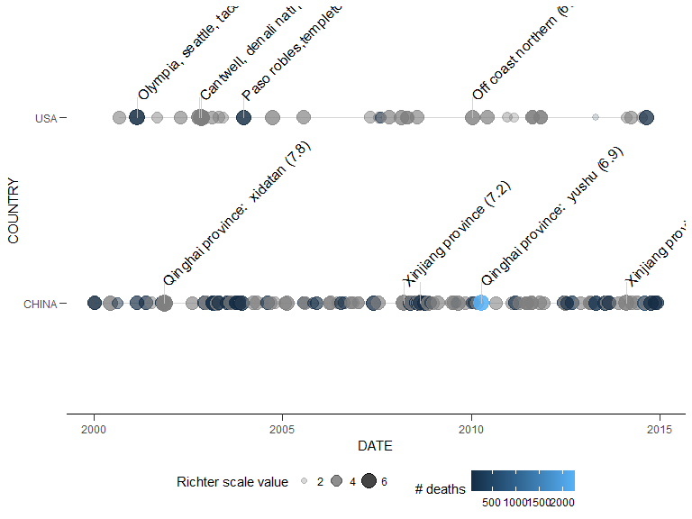

```r
h <- data %>%
 filter(YEAR >= 2000 & YEAR < 2015 & is.na(FLAG_TSUNAMI)) %>%
 filter(COUNTRY == "USA" | COUNTRY == "CHINA")

ggplot( h, aes (x = DATE )) +
  geom_timeline(
    aes(
      y = COUNTRY,
      size = EQ_PRIMARY,
      alpha = EQ_PRIMARY,
      colour = TOTAL_DEATHS
    )
    ) +
  scale_y_discrete() +
  theme_timeline() +
  labs(
    size = "Richter scale value",
    alpha = "Richter scale value",
    colour = "# deaths"
  ) +
  geom_timeline_label(
    aes(
      y = COUNTRY,
      n_max = 5,
      magnitude = EQ_PRIMARY,
      label = LOCATION_NAME
    )
  )
```

## Interactive eartquake map

The `eq_map()` function displays earthquakes on a interactive map as a leaflet. A small annotation popup is displayed when a user clicks on an earthquake point.

The `eq_create_label()` is a helper function, which could be used to make a popup text more informative.

Sample usage:

```r
h <- data %>%
 filter(YEAR >= 2000 & YEAR < 2015 & is.na(FLAG_TSUNAMI)) %>%
 filter(COUNTRY == "USA")
h %>%
  mutate(
    popup_text = eq_create_label(.)) %>%
  eq_map(annot_col = "popup_text")
```

[interactive chart not shown]